# Biostat 203B Homework 5

Due Mar 22 @ 11:59PM

Author

Yuxin Zhang 406328706

## Predicting ICU duration

Using the ICU cohort `mimiciv_icu_cohort.rds` you built in Homework 4, develop at least three machine learning approaches (logistic regression with enet regularization, random forest, boosting, SVM, MLP, etc) plus a model stacking approach for predicting whether a patient’s ICU stay will be longer than 2 days. You should use the `los_long` variable as the outcome. You algorithms can use patient demographic information (gender, age at ICU `intime`, marital status, race), ICU admission information (first care unit), the last lab measurements before the ICU stay, and first vital measurements during ICU stay as features. You are welcome to use any feature engineering techniques you think are appropriate; but make sure to not use features that are not available at an ICU stay’s `intime`. For instance, `last_careunit` cannot be used in your algorithms.

1. Data preprocessing and feature engineering.
2. Partition data into 50% training set and 50% test set. Stratify partitioning according to `los_long`. For grading purpose, sort the data by `subject_id`, `hadm_id`, and `stay_id` and use the seed `203` for the initial data split. Below is the sample code.

```r
library(tidyverse)
library(tidymodels)
library(gtsummary)
library(GGally)
library(gtsummary)
library(ranger)
library(ggplot2)
library(tune)
library(finetune)
library(keras)
library(stacks)
library(doParallel)
```

```r
registerDoParallel(cores = 5)
```

```r
set.seed(203)
mimiciv_icu_cohort <- readRDS("../hw4/mimiciv_shiny/mimic_icu_cohort.rds")
# sort
mimiciv_icu_cohort <- mimiciv_icu_cohort |>
  arrange(subject_id, hadm_id, stay_id) |>
  select(insurance, admission_type, admission_location,
         first_careunit, age_intime, gender, race, marital_status, 29:42 ) |>
  mutate(los_long = as.factor(los_long)) |>
  print(width = Inf)
```

```
# A tibble: 73,181 × 22
   insurance admission_type              admission_location
   <chr>     <fct>                       <fct>
 1 Medicaid  EW EMER.                    EMERGENCY ROOM
 2 Medicare  EW EMER.                    EMERGENCY ROOM
 3 Other     EW EMER.                    EMERGENCY ROOM
 4 Other     Other                       PHYSICIAN REFERRAL
 5 Other     EW EMER.                    Other
 6 Medicare  OBSERVATION ADMIT           EMERGENCY ROOM
 7 Medicare  SURGICAL SAME DAY ADMISSION PHYSICIAN REFERRAL
 8 Other     EW EMER.                    EMERGENCY ROOM
 9 Other     EW EMER.                    Other
10 Other     EW EMER.                    EMERGENCY ROOM
   first_careunit                                   age_intime gender race
   <fct>                                                 <int> <chr>  <fct>
```

[output cut: 59 more lines]

```r
attach(mimiciv_icu_cohort)
```

```r
data_split <- initial_split(
  mimiciv_icu_cohort,
  # stratify by los_long
  strata = "los_long",
  prop = 0.5
  )
```

```r
mimiciv_icu_cohort |> tbl_summary(by = los_long)
```

| **Characteristic** | **FALSE**, N = 38,050<sup>1</sup> | **TRUE**, N = 35,131<sup>1</sup> |
| --- | --- | --- |
| insurance |  |  |
| Medicaid | 3,060 (8.0%) | 2,468 (7.0%) |
| Medicare | 16,489 (43%) | 16,602 (47%) |
| Other | 18,501 (49%) | 16,061 (46%) |
| admission_type |  |  |
| EW EMER. | 20,735 (54%) | 17,937 (51%) |
| OBSERVATION ADMIT | 4,329 (11%) | 4,645 (13%) |
| SURGICAL SAME DAY ADMISSION | 4,340 (11%) | 3,033 (8.6%) |
| URGENT | 5,494 (14%) | 6,959 (20%) |
| Other | 3,152 (8.3%) | 2,557 (7.3%) |
| admission_location |  |  |
| EMERGENCY ROOM | 19,602 (52%) | 16,279 (46%) |
| PHYSICIAN REFERRAL | 8,986 (24%) | 7,412 (21%) |
| TRANSFER FROM HOSPITAL | 6,839 (18%) | 8,959 (26%) |
| WALK-IN/SELF REFERRAL | 876 (2.3%) | 791 (2.3%) |
| Other | 1,747 (4.6%) | 1,690 (4.8%) |
| first_careunit |  |  |
| Cardiac Vascular Intensive Care Unit (CVICU) | 5,827 (15%) | 5,755 (16%) |
| Medical Intensive Care Unit (MICU) | 8,782 (23%) | 7,116 (20%) |
| Medical/Surgical Intensive Care Unit (MICU/SICU) | 7,147 (19%) | 5,586 (16%) |
| Surgical Intensive Care Unit (SICU) | 5,654 (15%) | 5,507 (16%) |
| Other | 10,640 (28%) | 11,167 (32%) |
| age_intime | 65 (53, 77) | 67 (56, 78) |
| gender |  |  |
| F | 17,014 (45%) | 15,349 (44%) |
| M | 21,036 (55%) | 19,782 (56%) |
| race |  |  |
| ASIAN | 1,148 (3.0%) | 1,007 (2.9%) |
| BLACK | 4,311 (11%) | 3,649 (10%) |
| HISPANIC | 1,492 (3.9%) | 1,249 (3.6%) |
| Other | 5,160 (14%) | 5,596 (16%) |
| WHITE | 25,939 (68%) | 23,630 (67%) |
| marital_status |  |  |
| DIVORCED | 2,843 (8.0%) | 2,561 (7.9%) |
| MARRIED | 16,984 (48%) | 15,784 (49%) |
| SINGLE | 11,175 (31%) | 9,683 (30%) |
| WIDOWED | 4,699 (13%) | 4,339 (13%) |
| Unknown | 2,349 | 2,764 |
| creatinine | 1.00 (0.80, 1.40) | 1.00 (0.80, 1.60) |
| Unknown | 2,599 | 3,171 |
| sodium | 139.0 (136.0, 141.0) | 138.0 (135.0, 141.0) |
| Unknown | 4,174 | 4,698 |
| glucose | 118 (98, 153) | 122 (100, 159) |
| Unknown | 4,282 | 4,817 |
| potassium | 4.20 (3.80, 4.60) | 4.20 (3.80, 4.70) |
| Unknown | 4,189 | 4,712 |
| wbc | 9.0 (6.6, 12.6) | 9.7 (7.0, 13.8) |
| Unknown | 2,272 | 2,822 |
| bicarbonate | 25.0 (22.0, 27.0) | 24.0 (21.0, 27.0) |
| Unknown | 4,270 | 4,780 |
| chloride | 102 (98, 105) | 102 (98, 105) |
| Unknown | 4,175 | 4,708 |
| hematocrit | 36 (30, 40) | 35 (29, 40) |
| Unknown | 2,236 | 2,781 |
| Heart_Rate | 85 (74, 99) | 88 (76, 103) |
| Unknown | 17 | 1 |
| Temperature_Fahrenheit | 98.10 (97.60, 98.60) | 98.20 (97.60, 98.80) |
| Unknown | 1,189 | 173 |
| Non_Invasive_Blood_Pressure_systolic | 122 (107, 139) | 120 (104, 138) |
| Unknown | 732 | 247 |
| Non_Invasive_Blood_Pressure_diastolic | 68 (58, 80) | 66 (55, 79) |
| Unknown | 733 | 250 |
| Respiratory_Rate | 18.0 (15.0, 22.0) | 19.0 (15.0, 23.0) |
| Unknown | 87 | 11 |

<sup>1</sup> n (%); Median (IQR)

3. Train and tune the models using the training set.

### Model stacking

```r
mimic_other <- training(data_split)
dim(mimic_other)
```

```
[1] 36590    22
```

```r
mimic_test <- testing(data_split)
dim(mimic_test)
```

```
[1] 36591    22
```

```r
set.seed(203)

folds <- vfold_cv(mimic_other, v = 5)
folds
```

```
#  5-fold cross-validation
# A tibble: 5 × 2
  splits               id
  <list>               <chr>
1 <split [29272/7318]> Fold1
2 <split [29272/7318]> Fold2
3 <split [29272/7318]> Fold3
4 <split [29272/7318]> Fold4
5 <split [29272/7318]> Fold5
```

```r
logit_fit <- readRDS("logit_fit.rds")
rf_fit <- readRDS("rf_fit.rds")
gb_fit <- readRDS("gb_fit.rds")
```

```r
mimic_model_st <-
  # initialize the stack
  stacks() |>
  # add candidate members
  add_candidates(logit_fit) |>
  add_candidates(rf_fit) |>
  add_candidates(gb_fit) |>
  # determine how to combine their predictions
  blend_predictions(
    penalty = 10^(-6:2),
    metrics = c("roc_auc")
    ) |>
  # fit the candidates with nonzero stacking coefficients
  fit_members()
saveRDS(mimic_model_st, "mimic_model_st.rds")
```

```r
mimic_model_st <- readRDS("mimic_model_st.rds")
```

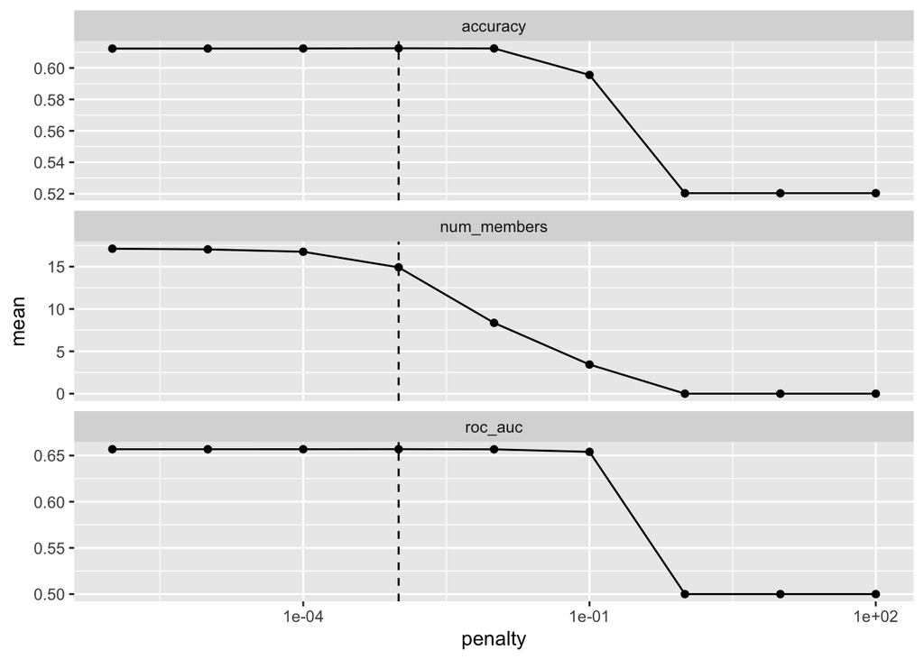

```r
autoplot(mimic_model_st)
```

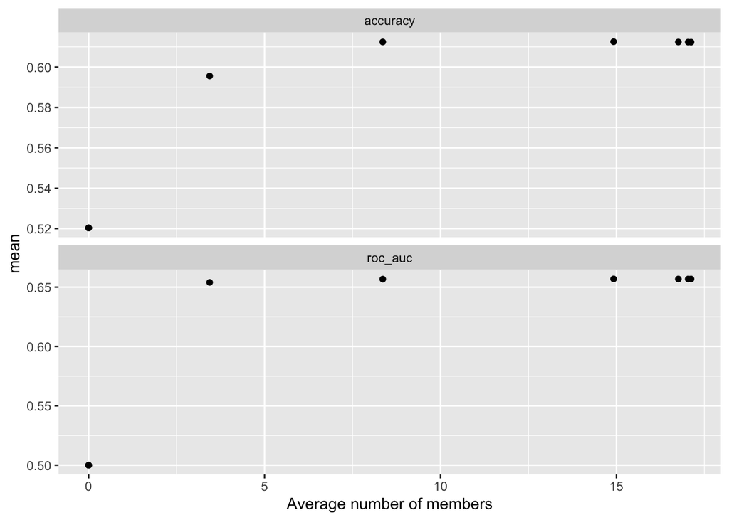

```r
autoplot(mimic_model_st, type = "members")
```

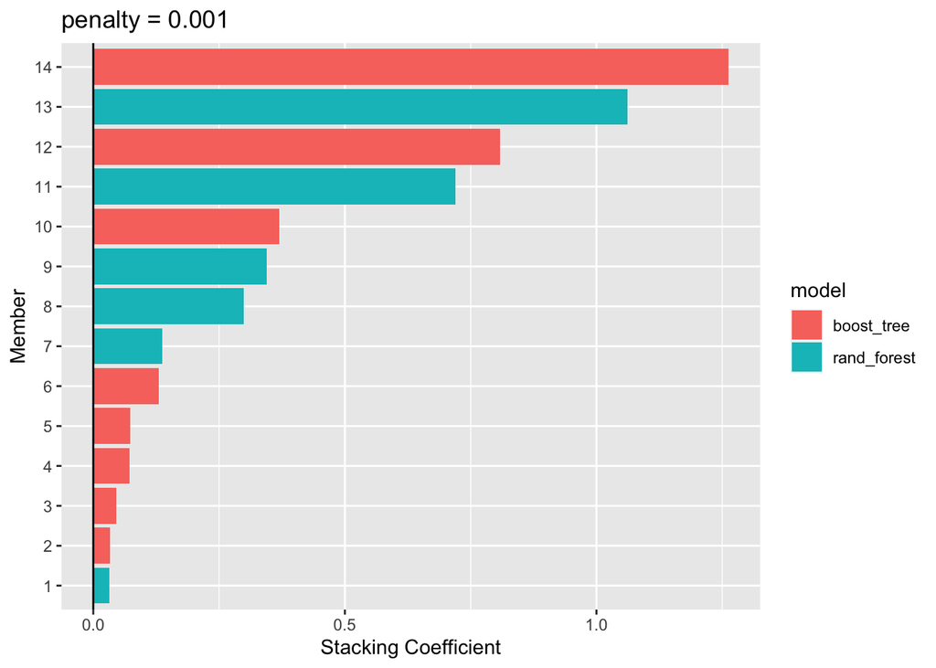

```r
autoplot(mimic_model_st, type = "weights")
```

```r
collect_parameters(mimic_model_st, "rf_fit")
```

```
# A tibble: 25 × 5
   member       mtry trees terms                    coef
   <chr>       <int> <int> <chr>                   <dbl>
 1 rf_fit_1_01     1   500 .pred_TRUE_rf_fit_1_01 0.0326
 2 rf_fit_1_02     1   625 .pred_TRUE_rf_fit_1_02 0
 3 rf_fit_1_03     1   750 .pred_TRUE_rf_fit_1_03 0
 4 rf_fit_1_04     1   875 .pred_TRUE_rf_fit_1_04 0
 5 rf_fit_1_05     1  1000 .pred_TRUE_rf_fit_1_05 0
 6 rf_fit_1_06     2   500 .pred_TRUE_rf_fit_1_06 0
 7 rf_fit_1_07     2   625 .pred_TRUE_rf_fit_1_07 0.137
 8 rf_fit_1_08     2   750 .pred_TRUE_rf_fit_1_08 1.06
 9 rf_fit_1_09     2   875 .pred_TRUE_rf_fit_1_09 0.344
10 rf_fit_1_10     2  1000 .pred_TRUE_rf_fit_1_10 0
# ℹ 15 more rows
```

```r
# final classification
mimic_pred <- mimic_test %>%
  bind_cols(predict(mimic_model_st, ., type = "prob")) %>%
  print(width = Inf)
```

```
# A tibble: 36,591 × 24
   insurance admission_type              admission_location
   <chr>     <fct>                       <fct>
 1 Medicaid  EW EMER.                    EMERGENCY ROOM
 2 Other     EW EMER.                    EMERGENCY ROOM
 3 Other     Other                       PHYSICIAN REFERRAL
 4 Other     EW EMER.                    Other
 5 Medicare  SURGICAL SAME DAY ADMISSION PHYSICIAN REFERRAL
 6 Other     EW EMER.                    Other
 7 Medicare  EW EMER.                    EMERGENCY ROOM
 8 Medicare  EW EMER.                    EMERGENCY ROOM
 9 Medicare  URGENT                      TRANSFER FROM HOSPITAL
10 Medicare  URGENT                      TRANSFER FROM HOSPITAL
   first_careunit                                   age_intime gender race
   <fct>                                                 <int> <chr>  <fct>
```

[output cut: 59 more lines]

```r
yardstick::roc_auc(
  mimic_pred,
  truth = los_long,
  contains(".pred_FALSE")
  )
```

```
# A tibble: 1 × 3
  .metric .estimator .estimate
  <chr>   <chr>          <dbl>
1 roc_auc binary         0.657
```

```r
threshold <- 0.5
predicted_labels <- ifelse(mimic_pred$.pred_TRUE > threshold, "TRUE", "FALSE")

# Convert the logical vector to a factor with explicit levels
predicted_factors <- factor(predicted_labels, levels = c("TRUE", "FALSE"))

# Ensure that the truth is also a factor with the same levels
truth_factors <- factor(mimic_test$los_long, levels = c("TRUE", "FALSE"))

# Calculate accuracy using accuracy_vec()
acc <- accuracy_vec(truth = truth_factors, estimate = predicted_factors)

# Print the accuracy
print(acc)
```

```
[1] 0.6108606
```

```r
mimic_pred <-
  mimic_test |>
  select(los_long) |>
  bind_cols(
    predict(
      mimic_model_st,
      mimic_test,
      type = "class",
      members = TRUE
      )
    ) |>
  print(width = Inf)
```

```
# A tibble: 36,591 × 16
   los_long .pred_class .pred_class_rf_fit_1_01 .pred_class_rf_fit_1_07
   <fct>    <fct>       <fct>                   <fct>
 1 FALSE    FALSE       FALSE                   FALSE
 2 FALSE    FALSE       FALSE                   FALSE
 3 FALSE    FALSE       FALSE                   FALSE
 4 FALSE    TRUE        TRUE                    TRUE
 5 FALSE    FALSE       FALSE                   FALSE
 6 TRUE     FALSE       TRUE                    TRUE
 7 TRUE     TRUE        TRUE                    TRUE
 8 TRUE     FALSE       FALSE                   TRUE
 9 TRUE     TRUE        TRUE                    TRUE
10 TRUE     TRUE        TRUE                    TRUE
   .pred_class_rf_fit_1_08 .pred_class_rf_fit_1_09 .pred_class_rf_fit_1_13
   <fct>                   <fct>                   <fct>
```

[output cut: 47 more lines]

```r
map(
  colnames(mimic_pred),
  ~mean(mimic_pred$los_long == pull(mimic_pred, .x))
  ) |>
  set_names(colnames(mimic_pred)) |>
  as_tibble() |>
  pivot_longer(c(everything(), -los_long))
```

```
# A tibble: 15 × 3
   los_long name                    value
      <dbl> <chr>                   <dbl>
 1        1 .pred_class             0.611
 2        1 .pred_class_rf_fit_1_01 0.603
 3        1 .pred_class_rf_fit_1_07 0.604
 4        1 .pred_class_rf_fit_1_08 0.604
 5        1 .pred_class_rf_fit_1_09 0.605
 6        1 .pred_class_rf_fit_1_13 0.604
 7        1 .pred_class_rf_fit_1_14 0.605
 8        1 .pred_class_gb_fit_1_19 0.600
 9        1 .pred_class_gb_fit_1_17 0.606
10        1 .pred_class_gb_fit_1_20 0.602
11        1 .pred_class_gb_fit_1_26 0.446
12        1 .pred_class_gb_fit_1_18 0.607
13        1 .pred_class_gb_fit_1_21 0.592
14        1 .pred_class_gb_fit_1_24 0.520
15        1 .pred_class_gb_fit_1_30 0.444
```

### Summary

Compare model classification performance on the test set. Report both the area under ROC curve and accuracy for each machine learning algorithm and the model stacking. Interpret the results. What are the most important features in predicting long ICU stays? How do the models compare in terms of performance and interpretability?

**Model Performance**  
The models’ performance metrics on the test set are as follows:

| Method | AUC | Accuracy |  |
| --- | --- | --- | --- |
| Logistic Regression | 0.606 | 0.579 |  |
| Random Forest | 0.645 | 0.603 |  |
| XGBoost | 0.649 | 0.606 |  |
| Stacked Model | 0.657 | 0.611 |  |

The stacked model exhibits the highest AUC, indicating a slightly better performance in distinguishing between patients with longer and shorter ICU stays. The AUC values suggest that Random Forest, XGBoost and the stacked model are generally more effective than the logistic regression model. However, the accuracy of all models is quite similar, with only slight variations.

**Model Interpretability**  
Logistic Regression offers the highest interpretability since it provides direct relationships between features and the outcome. Random Forest and XGBoost offer some interpretability through feature importance but are inherently more complex. The stacked model, while potentially offering the best performance, is the least interpretable due to the combination of multiple models.

**Trade-off between Performance and Interpretability**  
In conclusion, while the Stacked Model slightly outperforms the other models in terms of AUC and accuracy, this comes at the expense of interpretability. The choice between these models should be guided by the trade-off between the need for predictive accuracy and the requirement for model transparency.